# SSM Updated Simulations — Detailed Report

**10 locations · 4 genotypes (Non-LT, LT1.5, LT2, LT2.5) · 6 managements · 1990–2019 (30 years)**

Generated: 2026-05-29 · Data: `modeling_data/data/updated-outputs/`

## Experiment Design

The Sinclair Simplified Soybean Model (SSM) was used to simulate soybean growth and water use across **10 locations in three US states** (Arkansas, Missouri, and Nebraska) for the 30-year period 1990–2019. Each simulation represents one combination of location, genotype, water management, and planting date, run for each year independently.

### Locations

Locations were selected to span the major US soybean production belt, from the humid Mid-South to the semi-arid Great Plains:

| State | Locations | Climate |
| --- | --- | --- |
| Arkansas | Jonesboro, Keiser, Marianna, Rohwer | Humid subtropical; high VPD summers; drought risk during reproductive stages |
| Missouri | Albany, Mount Vernon, Novelty | Humid continental; moderate summer VPD; variable rainfall |
| Nebraska | Eustis, Lincoln, North Platte | Semi-arid to sub-humid; high summer VPD; irrigation-dependent production |

### Genotypes and the LT Trait

Four genotype classes were simulated using maturity groups matched to each region: **MG 4** for Arkansas and Missouri, and **MG 3** for Nebraska — chosen to approximate locally adapted commercial varieties and keep phenology comparable within each region:

[output not shown]

The LT trait is encoded in the SSM by a VPD-threshold response: when daily VPD exceeds the genotype-specific threshold, transpiration is capped at the rate reached at that VPD level, conserving soil water. Above-threshold days are common in all three states during July–August, making the LT trait agronomically relevant across the simulation domain.

### Water Management

Each genotype was simulated under two water management regimes:

- **Rainfed (RFD)** — no supplemental water; crop relies entirely on rainfall and stored soil water. This represents the majority of US soybean production.
- **Irrigated (IRRI)** — water is supplied on demand to keep the fraction of transpirable soil water (FTSW) above stress thresholds. This isolates the atmospheric demand effect (VPD) from soil water limitation, providing a cleaner signal of the LT trait's transpiration response.

### Planting Dates

Three planting dates were simulated per location to capture agronomic flexibility: **Early (ELY)**, **Mid (MID)**, and **Late (LTE)**. Results reported here are averaged across planting dates unless stated otherwise.

### Output Variables

| Variable | Description | Unit |
| --- | --- | --- |
| SUMETT | Seasonal total crop evapotranspiration (ETc) | mm season⁻¹ |
| Yield_kgha | Grain yield (WGRN × 10) | kg ha⁻¹ |
| WP | Water productivity (Yield / SUMETT) | kg mm⁻¹ |
| R7.PM | Days from planting to physiological maturity | days |
| ETc (daily) | Daily crop ET = TR (transpiration) + SEVP (soil evaporation) | mm day⁻¹ |
| LAI | Leaf area index | m² m⁻² |
| DDMP | Daily dry matter production | g m⁻² day⁻¹ |

## Overview: all locations

### Irrigated grain yield by location and genotype

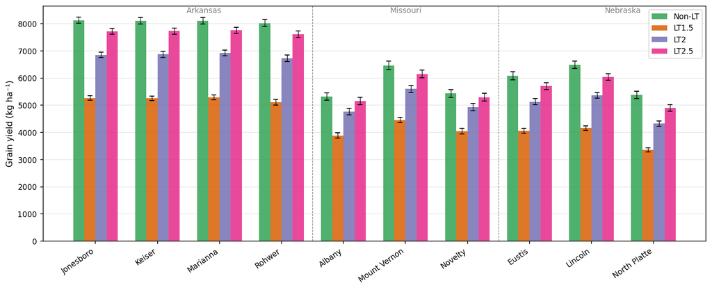

### Rainfed grain yield by location and genotype

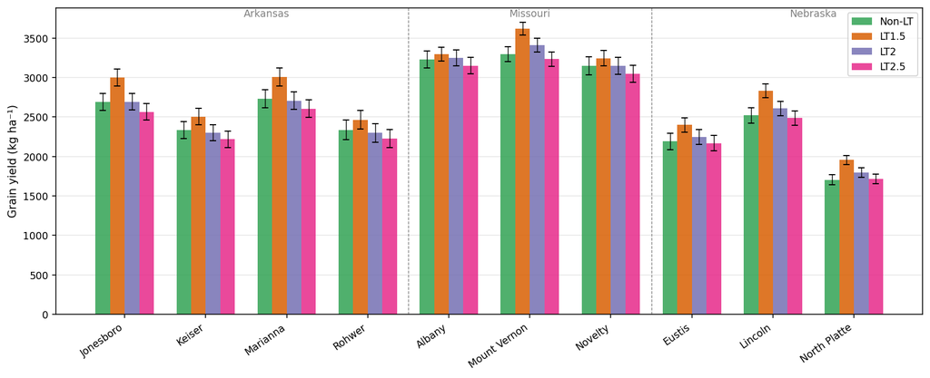

### Seasonal ETc (SUMETT) under irrigation by location and genotype

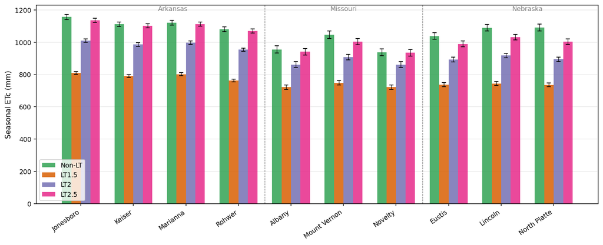

### Rainfed yield advantage of LT genotypes vs Non-LT (%)

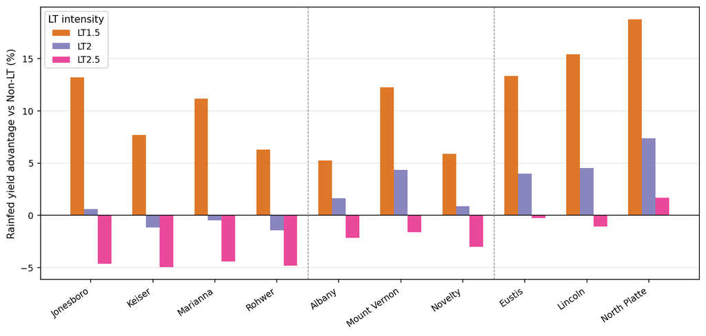

### Irrigation water saving (SUMETT reduction) of LT vs Non-LT

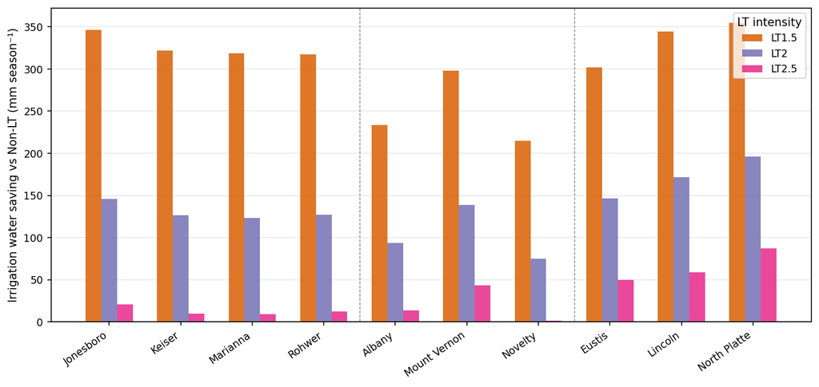

### Water productivity (yield / ETc) by water management and genotype

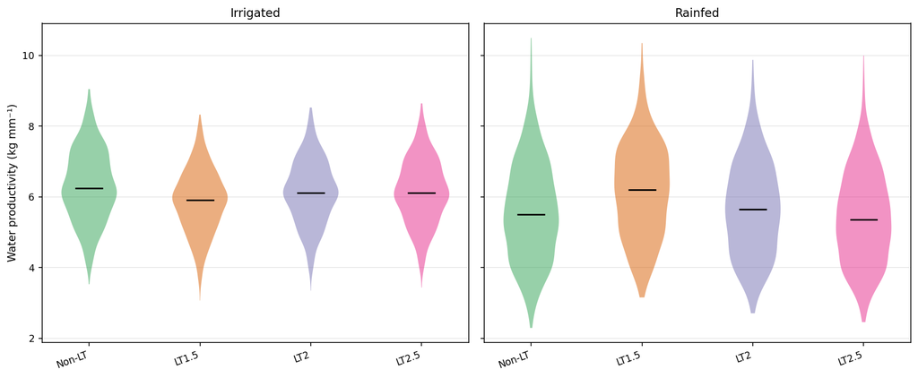

### Season length (days to R7.PM) under irrigation

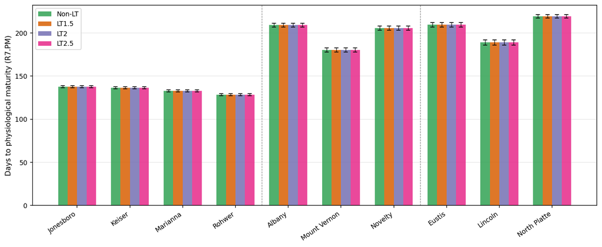

## Planting Date Effects

Each genotype was simulated under three planting dates — **Early**, **Mid**, and **Late** — per location. The overview figures above average across planting dates. This section isolates planting date as a factor to show how it modulates absolute yields, water use, and the LT trait advantage.

### P1 — Grain yield by planting date

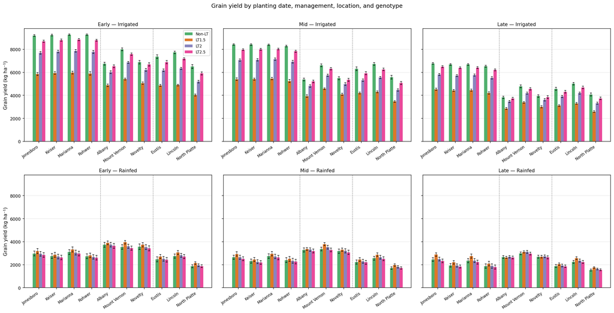

### P2 — LT trait advantage by planting date

Rainfed yield advantage (left) and irrigated water saving (right) of LT genotypes vs Non-LT, broken down by planting date. Bar fill indicates LT intensity (LT1.5 / LT2 / LT2.5); border colour indicates planting date (blue = Early, salmon = Mid, red = Late). A shift in advantage across planting dates indicates a planting date × genotype interaction.

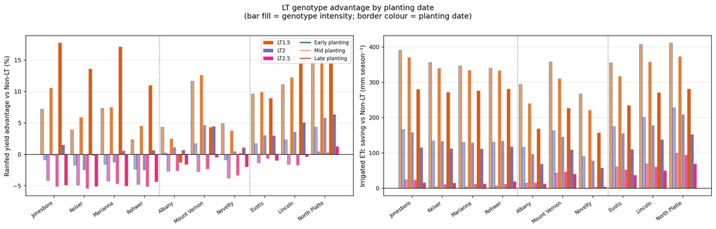

### P3 — Seasonal ETc (SUMETT) by planting date

Total growing-season crop ET by planting date, management, and genotype. Later planting dates generally reduce seasonal ETc because the crop experiences a shorter and often cooler growing period. The gap between Non-LT and LT genotypes (water savings) may widen or narrow depending on whether late planting aligns the crop season with peak VPD.

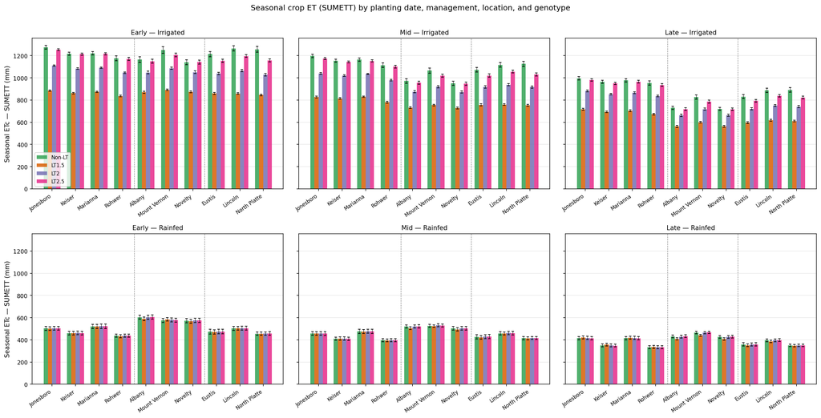

### P4 — Season length (R7.PM) by planting date

Days from planting to physiological maturity under irrigation, by planting date and genotype. Confirms the phenological effect of planting date and shows whether LT genotypes have systematically different cycle lengths than Non-LT within each planting window.

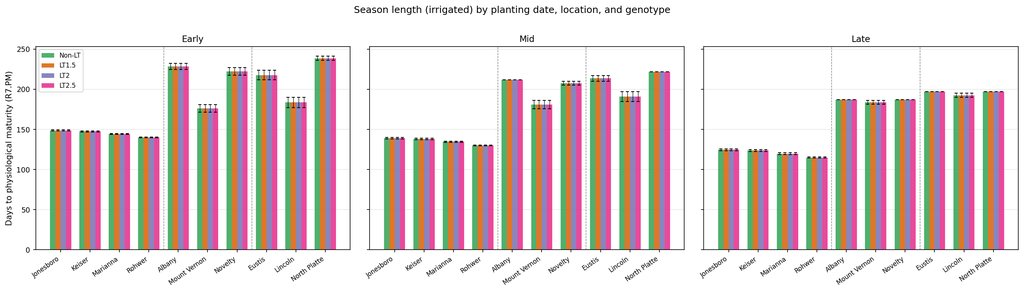

## Average Daily Crop ET (ETc) Analysis

Daily ETc = transpiration (TR) + soil evaporation (SEVP), using growing-season days only (DAP > 0). All values are based on 1,337,585 valid daily rows from the 10-location SSM simulation (1990–2019).

### D1 — Mean daily ETc by location, management, and genotype

Bars show the grand mean ± SE of all growing-season daily ETc values pooled across years and planting dates for each location × genotype × management combination.

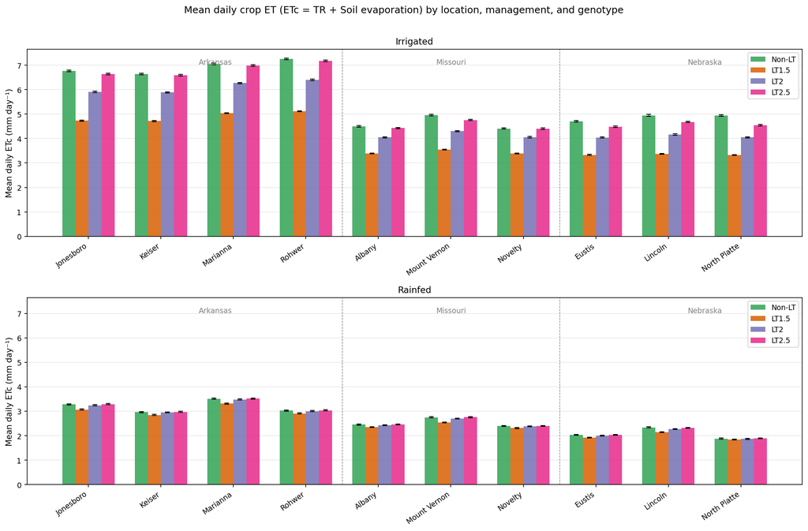

### D2 — Seasonal progression of daily ETc (5-day DAP bins)

ETc averaged within consecutive 5-day bins from planting to physiological maturity (full cycle), split by state and management. The thick dashed blue line is the mean daily PM ETo from NASA POWER (FAO-56 Penman-Monteith, state-level representative sites; averaged across 1990–2019 by DAP bin). Dotted grey lines mark approximate vegetative→reproductive transition (~DAP 50) and early reproductive→grain fill (~DAP 90). Irrigated and rainfed panels share the same y-axis. Season length varies by region: up to ~200 DAP in Arkansas, ~240 DAP in Missouri and Nebraska.

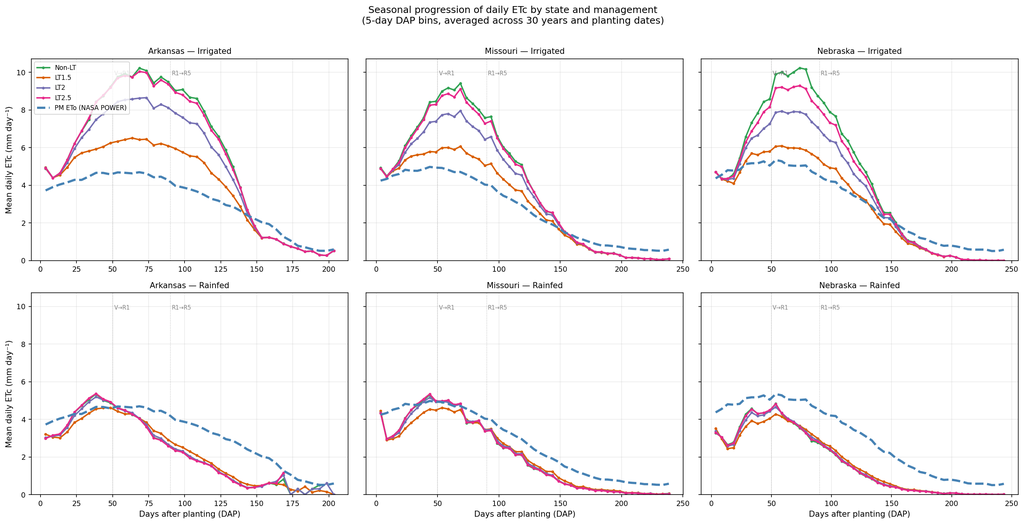

### D3 — Seasonal progression of Leaf Area Index (LAI)

Mean LAI (m² m⁻²) within 5-day DAP bins by state, management, and genotype. LAI trajectories reflect canopy development and senescence; differences among LT classes indicate the indirect effect of water conservation on leaf area maintenance during reproductive stages.

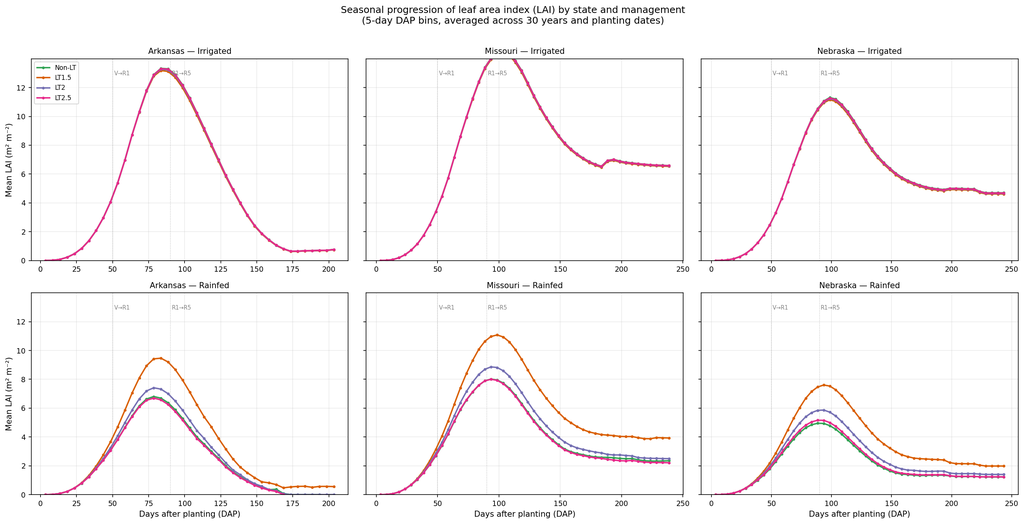

### D4 — Seasonal progression of daily dry matter production (DDMP)

Mean daily dry matter production (g m⁻² day⁻¹) within 5-day DAP bins by state, management, and genotype. DDMP integrates radiation interception and radiation use efficiency; comparing LT and Non-LT reveals whether water conservation translates into maintained or improved carbon assimilation.

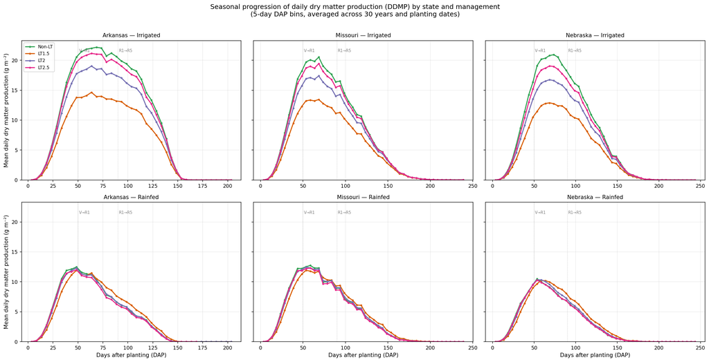

### D5 — Daily ETc reduction of LT genotypes relative to Non-LT

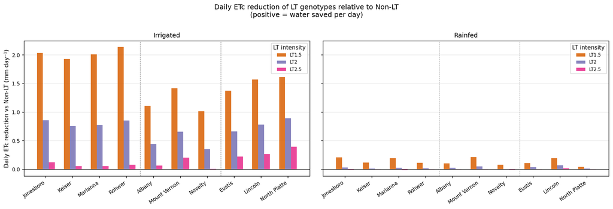

### D6 — Mean daily ETc summary table

Complete numerical summary by location, management, and genotype. Reduction column reports the absolute daily water saving relative to Non-LT (mm day⁻¹).

| Location | Management | Genotype | n days | Mean daily ETc (mm) | SD | Reduction vs Non-LT (mm day⁻¹) |
| --- | --- | --- | --- | --- | --- | --- |
| Jonesboro | Irrigated | Non-LT | 15335 | 6.765 | 4.332 | — |
| Jonesboro | Irrigated | LT1.5 | 15335 | 4.730 | 2.379 | +2.035 |
| Jonesboro | Irrigated | LT2 | 15335 | 5.907 | 3.300 | +0.858 |
| Jonesboro | Irrigated | LT2.5 | 15335 | 6.643 | 4.016 | +0.122 |
| Jonesboro | Rainfed | Non-LT | 12516 | 3.279 | 2.660 | — |
| Jonesboro | Rainfed | LT1.5 | 13429 | 3.071 | 2.128 | +0.208 |
| Jonesboro | Rainfed | LT2 | 12698 | 3.244 | 2.494 | +0.035 |
| Jonesboro | Rainfed | LT2.5 | 12476 | 3.290 | 2.660 | -0.011 |
| Keiser | Irrigated | Non-LT | 15012 | 6.644 | 4.118 | — |
| Keiser | Irrigated | LT1.5 | 15012 | 4.712 | 2.391 | +1.931 |
| Keiser | Irrigated | LT2 | 15012 | 5.887 | 3.263 | +0.757 |
| Keiser | Irrigated | LT2.5 | 15012 | 6.585 | 3.903 | +0.059 |
| Keiser | Rainfed | Non-LT | 12255 | 2.967 | 2.654 | — |
| Keiser | Rainfed | LT1.5 | 12850 | 2.847 | 2.172 | +0.120 |
| Keiser | Rainfed | LT2 | 12360 | 2.952 | 2.541 | +0.015 |
| Keiser | Rainfed | LT2.5 | 12231 | 2.972 | 2.686 | -0.006 |
| Marianna | Irrigated | Non-LT | 14268 | 7.049 | 3.960 | — |
| Marianna | Irrigated | LT1.5 | 14268 | 5.040 | 2.229 | +2.009 |
| Marianna | Irrigated | LT2 | 14268 | 6.271 | 3.087 | +0.778 |
| Marianna | Irrigated | LT2.5 | 14268 | 6.991 | 3.736 | +0.058 |
| Marianna | Rainfed | Non-LT | 12024 | 3.508 | 2.763 | — |
| Marianna | Rainfed | LT1.5 | 12750 | 3.311 | 2.253 | +0.198 |
| Marianna | Rainfed | LT2 | 12152 | 3.481 | 2.639 | +0.027 |
| Marianna | Rainfed | LT2.5 | 11998 | 3.521 | 2.779 | -0.013 |
| Rohwer | Irrigated | Non-LT | 13371 | 7.255 | 3.959 | — |
| Rohwer | Irrigated | LT1.5 | 13371 | 5.117 | 2.176 | +2.138 |
| Rohwer | Irrigated | LT2 | 13371 | 6.399 | 3.035 | +0.856 |
| Rohwer | Irrigated | LT2.5 | 13371 | 7.173 | 3.692 | +0.082 |
| Rohwer | Rainfed | Non-LT | 11516 | 3.026 | 2.626 | — |
| Rohwer | Rainfed | LT1.5 | 11922 | 2.910 | 2.152 | +0.116 |
| Rohwer | Rainfed | LT2 | 11595 | 3.007 | 2.496 | +0.019 |
| Rohwer | Rainfed | LT2.5 | 11503 | 3.033 | 2.637 | -0.007 |
| Albany | Irrigated | Non-LT | 19020 | 4.494 | 4.151 | — |
| Albany | Irrigated | LT1.5 | 19020 | 3.389 | 2.720 | +1.106 |
| Albany | Irrigated | LT2 | 19020 | 4.053 | 3.445 | +0.442 |
| Albany | Irrigated | LT2.5 | 19020 | 4.429 | 3.943 | +0.065 |
| Albany | Rainfed | Non-LT | 18845 | 2.454 | 2.719 | — |
| Albany | Rainfed | LT1.5 | 19020 | 2.347 | 2.257 | +0.107 |
| Albany | Rainfed | LT2 | 18998 | 2.427 | 2.565 | +0.027 |
| Albany | Rainfed | LT2.5 | 18868 | 2.458 | 2.704 | -0.005 |
| Mount Vernon | Irrigated | Non-LT | 18893 | 4.964 | 4.472 | — |
| Mount Vernon | Irrigated | LT1.5 | 18893 | 3.545 | 2.634 | +1.419 |
| Mount Vernon | Irrigated | LT2 | 18893 | 4.303 | 3.411 | +0.661 |
| Mount Vernon | Irrigated | LT2.5 | 18893 | 4.757 | 3.992 | +0.206 |
| Mount Vernon | Rainfed | Non-LT | 16964 | 2.753 | 2.705 | — |
| Mount Vernon | Rainfed | LT1.5 | 18169 | 2.536 | 2.208 | +0.217 |
| Mount Vernon | Rainfed | LT2 | 17372 | 2.702 | 2.557 | +0.051 |
| Mount Vernon | Rainfed | LT2.5 | 17001 | 2.756 | 2.700 | -0.003 |
| Novelty | Irrigated | Non-LT | 19020 | 4.408 | 4.001 | — |
| Novelty | Irrigated | LT1.5 | 19020 | 3.392 | 2.699 | +1.016 |
| Novelty | Irrigated | LT2 | 19020 | 4.054 | 3.422 | +0.354 |
| Novelty | Irrigated | LT2.5 | 19020 | 4.400 | 3.880 | +0.008 |
| Novelty | Rainfed | Non-LT | 18682 | 2.393 | 2.583 | — |
| Novelty | Rainfed | LT1.5 | 18893 | 2.310 | 2.210 | +0.083 |
| Novelty | Rainfed | LT2 | 18758 | 2.386 | 2.494 | +0.007 |
| Novelty | Rainfed | LT2.5 | 18680 | 2.401 | 2.609 | -0.008 |
| Eustis | Irrigated | Non-LT | 19770 | 4.705 | 4.552 | — |
| Eustis | Irrigated | LT1.5 | 19770 | 3.332 | 2.746 | +1.374 |
| Eustis | Irrigated | LT2 | 19770 | 4.040 | 3.495 | +0.665 |
| Eustis | Irrigated | LT2.5 | 19770 | 4.480 | 4.070 | +0.226 |
| Eustis | Rainfed | Non-LT | 18439 | 2.033 | 2.499 | — |
| Eustis | Rainfed | LT1.5 | 19237 | 1.921 | 2.101 | +0.112 |
| Eustis | Rainfed | LT2 | 18779 | 1.997 | 2.332 | +0.036 |
| Eustis | Rainfed | LT2.5 | 18549 | 2.028 | 2.454 | +0.005 |
| Lincoln | Irrigated | Non-LT | 19723 | 4.949 | 4.742 | — |
| Lincoln | Irrigated | LT1.5 | 19723 | 3.376 | 2.691 | +1.573 |
| Lincoln | Irrigated | LT2 | 19723 | 4.164 | 3.516 | +0.785 |
| Lincoln | Irrigated | LT2.5 | 19723 | 4.679 | 4.192 | +0.269 |
| Lincoln | Rainfed | Non-LT | 17299 | 2.337 | 2.637 | — |
| Lincoln | Rainfed | LT1.5 | 18733 | 2.140 | 2.132 | +0.197 |
| Lincoln | Rainfed | LT2 | 17899 | 2.266 | 2.432 | +0.071 |
| Lincoln | Rainfed | LT2.5 | 17477 | 2.319 | 2.592 | +0.018 |
| North Platte | Irrigated | Non-LT | 19770 | 4.943 | 4.823 | — |
| North Platte | Irrigated | LT1.5 | 19770 | 3.329 | 2.703 | +1.615 |
| North Platte | Irrigated | LT2 | 19770 | 4.051 | 3.449 | +0.893 |
| North Platte | Irrigated | LT2.5 | 19770 | 4.546 | 4.074 | +0.398 |
| North Platte | Rainfed | Non-LT | 19337 | 1.881 | 2.389 | — |
| North Platte | Rainfed | LT1.5 | 19700 | 1.836 | 2.067 | +0.045 |
| North Platte | Rainfed | LT2 | 19524 | 1.866 | 2.247 | +0.015 |
| North Platte | Rainfed | LT2.5 | 19359 | 1.884 | 2.340 | -0.003 |

## LT advantage summary across all locations

Mean irrigated ET saving, rainfed yield advantage, and irrigated yield penalty relative to Non-LT. All values are averages over planting dates and 30 simulation years.

| Location | LT genotype | ET saving irrigated (mm) | Rainfed yield advantage (%) | Irrigated yield penalty (%) |
| --- | --- | --- | --- | --- |
| Jonesboro | LT1.5 | 347 | +11.5 | -35.2 |
| Jonesboro | LT2 | 146 | +0.1 | -15.7 |
| Jonesboro | LT2.5 | 21 | -4.7 | -5.1 |
| Keiser | LT1.5 | 322 | +7.2 | -35.2 |
| Keiser | LT2 | 126 | -1.6 | -15.2 |
| Keiser | LT2.5 | 10 | -5.1 | -4.7 |
| Marianna | LT1.5 | 318 | +10.2 | -34.8 |
| Marianna | LT2 | 123 | -0.9 | -14.7 |
| Marianna | LT2.5 | 9 | -4.6 | -4.4 |
| Rohwer | LT1.5 | 318 | +5.4 | -36.3 |
| Rohwer | LT2 | 127 | -1.6 | -16.1 |
| Rohwer | LT2.5 | 12 | -4.8 | -5.2 |
| Albany | LT1.5 | 234 | +2.1 | -26.9 |
| Albany | LT2 | 93 | +0.7 | -10.4 |
| Albany | LT2.5 | 14 | -2.4 | -3.1 |
| Mount Vernon | LT1.5 | 298 | +9.7 | -31.0 |
| Mount Vernon | LT2 | 139 | +3.5 | -13.4 |
| Mount Vernon | LT2.5 | 43 | -1.9 | -4.8 |
| Novelty | LT1.5 | 215 | +3.1 | -25.4 |
| Novelty | LT2 | 75 | +0.1 | -9.2 |
| Novelty | LT2.5 | 2 | -3.1 | -2.5 |
| Eustis | LT1.5 | 302 | +9.5 | -33.2 |
| Eustis | LT2 | 146 | +2.5 | -15.6 |
| Eustis | LT2.5 | 50 | -1.0 | -6.2 |
| Lincoln | LT1.5 | 345 | +12.5 | -35.8 |
| Lincoln | LT2 | 172 | +3.5 | -17.3 |
| Lincoln | LT2.5 | 59 | -1.3 | -6.9 |
| North Platte | LT1.5 | 355 | +14.8 | -37.6 |
| North Platte | LT2 | 196 | +5.4 | -19.7 |
| North Platte | LT2.5 | 87 | +0.6 | -8.9 |

## Jonesboro (Arkansas)

Years: 1990–2019 N simulations: 360 irrigated · 360 rainfed

| Management | Genotype | n yrs | Yield (kg/ha) | ETc (mm) | WP (kg/mm) | R7.PM (d) |
| --- | --- | --- | --- | --- | --- | --- |
| Irrigated | Non-LT | 30 | 8125 ± 1082 | 1156 ± 146 | 7.04 ± 0.50 | 138 |
| Irrigated | LT1.5 | 30 | 5261 ± 778 | 809 ± 81 | 6.49 ± 0.58 | 138 |
| Irrigated | LT2 | 30 | 6851 ± 950 | 1010 ± 103 | 6.77 ± 0.50 | 138 |
| Irrigated | LT2.5 | 30 | 7713 ± 1021 | 1135 ± 126 | 6.79 ± 0.46 | 138 |
| Rainfed | Non-LT | 30 | 2692 ± 1031 | 458 ± 95 | 5.71 ± 1.33 | 122 |
| Rainfed | LT1.5 | 30 | 3001 ± 1000 | 461 ± 91 | 6.40 ± 1.33 | 127 |
| Rainfed | LT2 | 30 | 2693 ± 981 | 460 ± 95 | 5.72 ± 1.28 | 123 |
| Rainfed | LT2.5 | 30 | 2565 ± 978 | 458 ± 96 | 5.45 ± 1.26 | 122 |

## Keiser (Arkansas)

Years: 1990–2019 N simulations: 360 irrigated · 360 rainfed

| Management | Genotype | n yrs | Yield (kg/ha) | ETc (mm) | WP (kg/mm) | R7.PM (d) |
| --- | --- | --- | --- | --- | --- | --- |
| Irrigated | Non-LT | 30 | 8104 ± 1131 | 1112 ± 129 | 7.29 ± 0.52 | 136 |
| Irrigated | LT1.5 | 30 | 5254 ± 813 | 790 ± 79 | 6.63 ± 0.53 | 136 |
| Irrigated | LT2 | 30 | 6872 ± 1014 | 986 ± 104 | 6.95 ± 0.50 | 136 |
| Irrigated | LT2.5 | 30 | 7726 ± 1095 | 1102 ± 122 | 7.00 ± 0.47 | 136 |
| Rainfed | Non-LT | 30 | 2337 ± 1019 | 407 ± 94 | 5.55 ± 1.45 | 120 |
| Rainfed | LT1.5 | 30 | 2506 ± 1005 | 410 ± 92 | 5.95 ± 1.45 | 124 |
| Rainfed | LT2 | 30 | 2301 ± 972 | 408 ± 94 | 5.46 ± 1.38 | 121 |
| Rainfed | LT2.5 | 30 | 2218 ± 962 | 407 ± 94 | 5.27 ± 1.37 | 120 |

## Marianna (Arkansas)

Years: 1990–2019 N simulations: 360 irrigated · 360 rainfed

| Management | Genotype | n yrs | Yield (kg/ha) | ETc (mm) | WP (kg/mm) | R7.PM (d) |
| --- | --- | --- | --- | --- | --- | --- |
| Irrigated | Non-LT | 30 | 8113 ± 1134 | 1121 ± 133 | 7.24 ± 0.61 | 133 |
| Irrigated | LT1.5 | 30 | 5293 ± 848 | 802 ± 81 | 6.58 ± 0.62 | 133 |
| Irrigated | LT2 | 30 | 6920 ± 1030 | 997 ± 102 | 6.92 ± 0.57 | 133 |
| Irrigated | LT2.5 | 30 | 7757 ± 1098 | 1111 ± 120 | 6.97 ± 0.57 | 133 |
| Rainfed | Non-LT | 30 | 2732 ± 1101 | 471 ± 106 | 5.65 ± 1.32 | 119 |
| Rainfed | LT1.5 | 30 | 3009 ± 1092 | 471 ± 101 | 6.26 ± 1.33 | 124 |
| Rainfed | LT2 | 30 | 2708 ± 1063 | 472 ± 106 | 5.60 ± 1.27 | 120 |
| Rainfed | LT2.5 | 30 | 2606 ± 1049 | 472 ± 107 | 5.38 ± 1.25 | 119 |

## Rohwer (Arkansas)

Years: 1990–2019 N simulations: 360 irrigated · 360 rainfed

| Management | Genotype | n yrs | Yield (kg/ha) | ETc (mm) | WP (kg/mm) | R7.PM (d) |
| --- | --- | --- | --- | --- | --- | --- |
| Irrigated | Non-LT | 30 | 8023 ± 1201 | 1081 ± 145 | 7.45 ± 0.79 | 128 |
| Irrigated | LT1.5 | 30 | 5115 ± 986 | 763 ± 80 | 6.67 ± 0.84 | 128 |
| Irrigated | LT2 | 30 | 6733 ± 1130 | 954 ± 98 | 7.04 ± 0.78 | 128 |
| Irrigated | LT2.5 | 30 | 7609 ± 1164 | 1069 ± 122 | 7.12 ± 0.74 | 128 |
| Rainfed | Non-LT | 30 | 2338 ± 1150 | 390 ± 85 | 5.75 ± 1.85 | 114 |
| Rainfed | LT1.5 | 30 | 2464 ± 1126 | 388 ± 83 | 6.11 ± 1.80 | 118 |
| Rainfed | LT2 | 30 | 2300 ± 1111 | 390 ± 86 | 5.66 ± 1.76 | 115 |
| Rainfed | LT2.5 | 30 | 2226 ± 1094 | 390 ± 86 | 5.47 ± 1.74 | 114 |

## Albany (Missouri)

Years: 1990–2019 N simulations: 360 irrigated · 360 rainfed

| Management | Genotype | n yrs | Yield (kg/ha) | ETc (mm) | WP (kg/mm) | R7.PM (d) |
| --- | --- | --- | --- | --- | --- | --- |
| Irrigated | Non-LT | 30 | 5320 ± 1342 | 955 ± 211 | 5.57 ± 0.70 | 209 |
| Irrigated | LT1.5 | 30 | 3889 ± 985 | 721 ± 134 | 5.36 ± 0.71 | 209 |
| Irrigated | LT2 | 30 | 4765 ± 1188 | 862 ± 168 | 5.50 ± 0.66 | 209 |
| Irrigated | LT2.5 | 30 | 5155 ± 1294 | 941 ± 195 | 5.45 ± 0.63 | 209 |
| Rainfed | Non-LT | 30 | 3228 ± 1035 | 519 ± 109 | 6.15 ± 1.09 | 180 |
| Rainfed | LT1.5 | 30 | 3297 ± 847 | 501 ± 104 | 6.56 ± 0.83 | 199 |
| Rainfed | LT2 | 30 | 3249 ± 956 | 517 ± 108 | 6.24 ± 0.96 | 185 |
| Rainfed | LT2.5 | 30 | 3151 ± 995 | 520 ± 110 | 5.99 ± 1.02 | 181 |

## Mount Vernon (Missouri)

Years: 1990–2019 N simulations: 360 irrigated · 360 rainfed

| Management | Genotype | n yrs | Yield (kg/ha) | ETc (mm) | WP (kg/mm) | R7.PM (d) |
| --- | --- | --- | --- | --- | --- | --- |
| Irrigated | Non-LT | 30 | 6463 ± 1478 | 1047 ± 220 | 6.16 ± 0.56 | 180 |
| Irrigated | LT1.5 | 30 | 4458 ± 918 | 749 ± 126 | 5.92 ± 0.47 | 180 |
| Irrigated | LT2 | 30 | 5599 ± 1202 | 908 ± 161 | 6.13 ± 0.46 | 180 |
| Irrigated | LT2.5 | 30 | 6150 ± 1364 | 1003 ± 190 | 6.10 ± 0.46 | 180 |
| Rainfed | Non-LT | 30 | 3296 ± 907 | 523 ± 89 | 6.26 ± 1.16 | 146 |
| Rainfed | LT1.5 | 30 | 3618 ± 772 | 516 ± 89 | 7.01 ± 0.95 | 166 |
| Rainfed | LT2 | 30 | 3412 ± 843 | 526 ± 89 | 6.47 ± 1.12 | 152 |
| Rainfed | LT2.5 | 30 | 3233 ± 862 | 525 ± 89 | 6.13 ± 1.12 | 147 |

## Novelty (Missouri)

Years: 1990–2019 N simulations: 360 irrigated · 360 rainfed

| Management | Genotype | n yrs | Yield (kg/ha) | ETc (mm) | WP (kg/mm) | R7.PM (d) |
| --- | --- | --- | --- | --- | --- | --- |
| Irrigated | Non-LT | 30 | 5433 ± 1412 | 937 ± 201 | 5.76 ± 0.60 | 206 |
| Irrigated | LT1.5 | 30 | 4052 ± 985 | 722 ± 135 | 5.57 ± 0.59 | 206 |
| Irrigated | LT2 | 30 | 4932 ± 1231 | 862 ± 169 | 5.68 ± 0.56 | 206 |
| Irrigated | LT2.5 | 30 | 5294 ± 1353 | 935 ± 193 | 5.62 ± 0.55 | 206 |
| Rainfed | Non-LT | 30 | 3146 ± 1082 | 501 ± 107 | 6.17 ± 1.15 | 172 |
| Rainfed | LT1.5 | 30 | 3244 ± 920 | 490 ± 102 | 6.59 ± 1.00 | 188 |
| Rainfed | LT2 | 30 | 3149 ± 1012 | 502 ± 107 | 6.21 ± 1.09 | 176 |
| Rainfed | LT2.5 | 30 | 3047 ± 1036 | 503 ± 108 | 5.97 ± 1.10 | 172 |

## Eustis (Nebraska)

Years: 1990–2019 N simulations: 360 irrigated · 360 rainfed

| Management | Genotype | n yrs | Yield (kg/ha) | ETc (mm) | WP (kg/mm) | R7.PM (d) |
| --- | --- | --- | --- | --- | --- | --- |
| Irrigated | Non-LT | 30 | 6081 ± 1406 | 1039 ± 196 | 5.82 ± 0.49 | 209 |
| Irrigated | LT1.5 | 30 | 4064 ± 835 | 737 ± 118 | 5.49 ± 0.51 | 209 |
| Irrigated | LT2 | 30 | 5130 ± 1094 | 892 ± 144 | 5.71 ± 0.49 | 209 |
| Irrigated | LT2.5 | 30 | 5702 ± 1262 | 989 ± 169 | 5.72 ± 0.49 | 209 |
| Rainfed | Non-LT | 30 | 2192 ± 977 | 420 ± 110 | 5.07 ± 1.16 | 154 |
| Rainfed | LT1.5 | 30 | 2400 ± 855 | 415 ± 101 | 5.73 ± 1.16 | 171 |
| Rainfed | LT2 | 30 | 2247 ± 908 | 420 ± 108 | 5.24 ± 1.12 | 161 |
| Rainfed | LT2.5 | 30 | 2170 ± 930 | 421 ± 110 | 5.02 ± 1.09 | 154 |

## Lincoln (Nebraska)

Years: 1990–2019 N simulations: 360 irrigated · 360 rainfed

| Management | Genotype | n yrs | Yield (kg/ha) | ETc (mm) | WP (kg/mm) | R7.PM (d) |
| --- | --- | --- | --- | --- | --- | --- |
| Irrigated | Non-LT | 30 | 6486 ± 1289 | 1089 ± 192 | 5.94 ± 0.49 | 189 |
| Irrigated | LT1.5 | 30 | 4165 ± 772 | 745 ± 107 | 5.57 ± 0.49 | 189 |
| Irrigated | LT2 | 30 | 5363 ± 1012 | 917 ± 139 | 5.82 ± 0.46 | 189 |
| Irrigated | LT2.5 | 30 | 6042 ± 1167 | 1030 ± 162 | 5.84 ± 0.45 | 189 |
| Rainfed | Non-LT | 30 | 2520 ± 897 | 453 ± 94 | 5.45 ± 1.19 | 142 |
| Rainfed | LT1.5 | 30 | 2834 ± 814 | 450 ± 91 | 6.27 ± 1.26 | 160 |
| Rainfed | LT2 | 30 | 2609 ± 853 | 454 ± 93 | 5.66 ± 1.19 | 147 |
| Rainfed | LT2.5 | 30 | 2488 ± 869 | 454 ± 95 | 5.37 ± 1.17 | 142 |

## North Platte (Nebraska)

Years: 1990–2019 N simulations: 360 irrigated · 360 rainfed

| Management | Genotype | n yrs | Yield (kg/ha) | ETc (mm) | WP (kg/mm) | R7.PM (d) |
| --- | --- | --- | --- | --- | --- | --- |
| Irrigated | Non-LT | 30 | 5383 ± 1318 | 1091 ± 199 | 4.89 ± 0.50 | 219 |
| Irrigated | LT1.5 | 30 | 3357 ± 716 | 736 ± 106 | 4.53 ± 0.51 | 219 |
| Irrigated | LT2 | 30 | 4324 ± 947 | 895 ± 131 | 4.79 ± 0.50 | 219 |
| Irrigated | LT2.5 | 30 | 4904 ± 1116 | 1003 ± 158 | 4.84 ± 0.49 | 219 |
| Rainfed | Non-LT | 30 | 1705 ± 608 | 407 ± 87 | 4.11 ± 0.88 | 170 |
| Rainfed | LT1.5 | 30 | 1957 ± 538 | 405 ± 83 | 4.81 ± 0.81 | 191 |
| Rainfed | LT2 | 30 | 1797 ± 555 | 408 ± 85 | 4.37 ± 0.81 | 175 |
| Rainfed | LT2.5 | 30 | 1715 ± 569 | 408 ± 86 | 4.14 ± 0.82 | 172 |

## Overall summary statistics

| Location | Water mgmt | Genotype | n (years) | Yield mean (kg/ha) | SUMETT mean (mm) | WP mean (kg/mm) | R7PM mean (days) |
| --- | --- | --- | --- | --- | --- | --- | --- |
| Jonesboro | Irrigated | Non-LT | 30 | 8125 ± 1082 | 1156 ± 146 | 7.04 ± 0.50 | 138 |
| Jonesboro | Irrigated | LT1.5 | 30 | 5261 ± 778 | 809 ± 81 | 6.49 ± 0.58 | 138 |
| Jonesboro | Irrigated | LT2 | 30 | 6851 ± 950 | 1010 ± 103 | 6.77 ± 0.50 | 138 |
| Jonesboro | Irrigated | LT2.5 | 30 | 7713 ± 1021 | 1135 ± 126 | 6.79 ± 0.46 | 138 |
| Jonesboro | Rainfed | Non-LT | 30 | 2692 ± 1031 | 458 ± 95 | 5.71 ± 1.33 | 122 |
| Jonesboro | Rainfed | LT1.5 | 30 | 3001 ± 1000 | 461 ± 91 | 6.40 ± 1.33 | 127 |
| Jonesboro | Rainfed | LT2 | 30 | 2693 ± 981 | 460 ± 95 | 5.72 ± 1.28 | 123 |
| Jonesboro | Rainfed | LT2.5 | 30 | 2565 ± 978 | 458 ± 96 | 5.45 ± 1.26 | 122 |
| Keiser | Irrigated | Non-LT | 30 | 8104 ± 1131 | 1112 ± 129 | 7.29 ± 0.52 | 136 |
| Keiser | Irrigated | LT1.5 | 30 | 5254 ± 813 | 790 ± 79 | 6.63 ± 0.53 | 136 |
| Keiser | Irrigated | LT2 | 30 | 6872 ± 1014 | 986 ± 104 | 6.95 ± 0.50 | 136 |
| Keiser | Irrigated | LT2.5 | 30 | 7726 ± 1095 | 1102 ± 122 | 7.00 ± 0.47 | 136 |
| Keiser | Rainfed | Non-LT | 30 | 2337 ± 1019 | 407 ± 94 | 5.55 ± 1.45 | 120 |
| Keiser | Rainfed | LT1.5 | 30 | 2506 ± 1005 | 410 ± 92 | 5.95 ± 1.45 | 124 |
| Keiser | Rainfed | LT2 | 30 | 2301 ± 972 | 408 ± 94 | 5.46 ± 1.38 | 121 |
| Keiser | Rainfed | LT2.5 | 30 | 2218 ± 962 | 407 ± 94 | 5.27 ± 1.37 | 120 |
| Marianna | Irrigated | Non-LT | 30 | 8113 ± 1134 | 1121 ± 133 | 7.24 ± 0.61 | 133 |
| Marianna | Irrigated | LT1.5 | 30 | 5293 ± 848 | 802 ± 81 | 6.58 ± 0.62 | 133 |
| Marianna | Irrigated | LT2 | 30 | 6920 ± 1030 | 997 ± 102 | 6.92 ± 0.57 | 133 |
| Marianna | Irrigated | LT2.5 | 30 | 7757 ± 1098 | 1111 ± 120 | 6.97 ± 0.57 | 133 |
| Marianna | Rainfed | Non-LT | 30 | 2732 ± 1101 | 471 ± 106 | 5.65 ± 1.32 | 119 |
| Marianna | Rainfed | LT1.5 | 30 | 3009 ± 1092 | 471 ± 101 | 6.26 ± 1.33 | 124 |
| Marianna | Rainfed | LT2 | 30 | 2708 ± 1063 | 472 ± 106 | 5.60 ± 1.27 | 120 |
| Marianna | Rainfed | LT2.5 | 30 | 2606 ± 1049 | 472 ± 107 | 5.38 ± 1.25 | 119 |
| Rohwer | Irrigated | Non-LT | 30 | 8023 ± 1201 | 1081 ± 145 | 7.45 ± 0.79 | 128 |
| Rohwer | Irrigated | LT1.5 | 30 | 5115 ± 986 | 763 ± 80 | 6.67 ± 0.84 | 128 |
| Rohwer | Irrigated | LT2 | 30 | 6733 ± 1130 | 954 ± 98 | 7.04 ± 0.78 | 128 |
| Rohwer | Irrigated | LT2.5 | 30 | 7609 ± 1164 | 1069 ± 122 | 7.12 ± 0.74 | 128 |
| Rohwer | Rainfed | Non-LT | 30 | 2338 ± 1150 | 390 ± 85 | 5.75 ± 1.85 | 114 |
| Rohwer | Rainfed | LT1.5 | 30 | 2464 ± 1126 | 388 ± 83 | 6.11 ± 1.80 | 118 |
| Rohwer | Rainfed | LT2 | 30 | 2300 ± 1111 | 390 ± 86 | 5.66 ± 1.76 | 115 |
| Rohwer | Rainfed | LT2.5 | 30 | 2226 ± 1094 | 390 ± 86 | 5.47 ± 1.74 | 114 |
| Albany | Irrigated | Non-LT | 30 | 5320 ± 1342 | 955 ± 211 | 5.57 ± 0.70 | 209 |
| Albany | Irrigated | LT1.5 | 30 | 3889 ± 985 | 721 ± 134 | 5.36 ± 0.71 | 209 |
| Albany | Irrigated | LT2 | 30 | 4765 ± 1188 | 862 ± 168 | 5.50 ± 0.66 | 209 |
| Albany | Irrigated | LT2.5 | 30 | 5155 ± 1294 | 941 ± 195 | 5.45 ± 0.63 | 209 |
| Albany | Rainfed | Non-LT | 30 | 3228 ± 1035 | 519 ± 109 | 6.15 ± 1.09 | 180 |
| Albany | Rainfed | LT1.5 | 30 | 3297 ± 847 | 501 ± 104 | 6.56 ± 0.83 | 199 |
| Albany | Rainfed | LT2 | 30 | 3249 ± 956 | 517 ± 108 | 6.24 ± 0.96 | 185 |
| Albany | Rainfed | LT2.5 | 30 | 3151 ± 995 | 520 ± 110 | 5.99 ± 1.02 | 181 |
| Mount Vernon | Irrigated | Non-LT | 30 | 6463 ± 1478 | 1047 ± 220 | 6.16 ± 0.56 | 180 |
| Mount Vernon | Irrigated | LT1.5 | 30 | 4458 ± 918 | 749 ± 126 | 5.92 ± 0.47 | 180 |
| Mount Vernon | Irrigated | LT2 | 30 | 5599 ± 1202 | 908 ± 161 | 6.13 ± 0.46 | 180 |
| Mount Vernon | Irrigated | LT2.5 | 30 | 6150 ± 1364 | 1003 ± 190 | 6.10 ± 0.46 | 180 |
| Mount Vernon | Rainfed | Non-LT | 30 | 3296 ± 907 | 523 ± 89 | 6.26 ± 1.16 | 146 |
| Mount Vernon | Rainfed | LT1.5 | 30 | 3618 ± 772 | 516 ± 89 | 7.01 ± 0.95 | 166 |
| Mount Vernon | Rainfed | LT2 | 30 | 3412 ± 843 | 526 ± 89 | 6.47 ± 1.12 | 152 |
| Mount Vernon | Rainfed | LT2.5 | 30 | 3233 ± 862 | 525 ± 89 | 6.13 ± 1.12 | 147 |
| Novelty | Irrigated | Non-LT | 30 | 5433 ± 1412 | 937 ± 201 | 5.76 ± 0.60 | 206 |
| Novelty | Irrigated | LT1.5 | 30 | 4052 ± 985 | 722 ± 135 | 5.57 ± 0.59 | 206 |
| Novelty | Irrigated | LT2 | 30 | 4932 ± 1231 | 862 ± 169 | 5.68 ± 0.56 | 206 |
| Novelty | Irrigated | LT2.5 | 30 | 5294 ± 1353 | 935 ± 193 | 5.62 ± 0.55 | 206 |
| Novelty | Rainfed | Non-LT | 30 | 3146 ± 1082 | 501 ± 107 | 6.17 ± 1.15 | 172 |
| Novelty | Rainfed | LT1.5 | 30 | 3244 ± 920 | 490 ± 102 | 6.59 ± 1.00 | 188 |
| Novelty | Rainfed | LT2 | 30 | 3149 ± 1012 | 502 ± 107 | 6.21 ± 1.09 | 176 |
| Novelty | Rainfed | LT2.5 | 30 | 3047 ± 1036 | 503 ± 108 | 5.97 ± 1.10 | 172 |
| Eustis | Irrigated | Non-LT | 30 | 6081 ± 1406 | 1039 ± 196 | 5.82 ± 0.49 | 209 |
| Eustis | Irrigated | LT1.5 | 30 | 4064 ± 835 | 737 ± 118 | 5.49 ± 0.51 | 209 |
| Eustis | Irrigated | LT2 | 30 | 5130 ± 1094 | 892 ± 144 | 5.71 ± 0.49 | 209 |
| Eustis | Irrigated | LT2.5 | 30 | 5702 ± 1262 | 989 ± 169 | 5.72 ± 0.49 | 209 |
| Eustis | Rainfed | Non-LT | 30 | 2192 ± 977 | 420 ± 110 | 5.07 ± 1.16 | 154 |
| Eustis | Rainfed | LT1.5 | 30 | 2400 ± 855 | 415 ± 101 | 5.73 ± 1.16 | 171 |
| Eustis | Rainfed | LT2 | 30 | 2247 ± 908 | 420 ± 108 | 5.24 ± 1.12 | 161 |
| Eustis | Rainfed | LT2.5 | 30 | 2170 ± 930 | 421 ± 110 | 5.02 ± 1.09 | 154 |
| Lincoln | Irrigated | Non-LT | 30 | 6486 ± 1289 | 1089 ± 192 | 5.94 ± 0.49 | 189 |
| Lincoln | Irrigated | LT1.5 | 30 | 4165 ± 772 | 745 ± 107 | 5.57 ± 0.49 | 189 |
| Lincoln | Irrigated | LT2 | 30 | 5363 ± 1012 | 917 ± 139 | 5.82 ± 0.46 | 189 |
| Lincoln | Irrigated | LT2.5 | 30 | 6042 ± 1167 | 1030 ± 162 | 5.84 ± 0.45 | 189 |
| Lincoln | Rainfed | Non-LT | 30 | 2520 ± 897 | 453 ± 94 | 5.45 ± 1.19 | 142 |
| Lincoln | Rainfed | LT1.5 | 30 | 2834 ± 814 | 450 ± 91 | 6.27 ± 1.26 | 160 |
| Lincoln | Rainfed | LT2 | 30 | 2609 ± 853 | 454 ± 93 | 5.66 ± 1.19 | 147 |
| Lincoln | Rainfed | LT2.5 | 30 | 2488 ± 869 | 454 ± 95 | 5.37 ± 1.17 | 142 |
| North Platte | Irrigated | Non-LT | 30 | 5383 ± 1318 | 1091 ± 199 | 4.89 ± 0.50 | 219 |
| North Platte | Irrigated | LT1.5 | 30 | 3357 ± 716 | 736 ± 106 | 4.53 ± 0.51 | 219 |
| North Platte | Irrigated | LT2 | 30 | 4324 ± 947 | 895 ± 131 | 4.79 ± 0.50 | 219 |
| North Platte | Irrigated | LT2.5 | 30 | 4904 ± 1116 | 1003 ± 158 | 4.84 ± 0.49 | 219 |
| North Platte | Rainfed | Non-LT | 30 | 1705 ± 608 | 407 ± 87 | 4.11 ± 0.88 | 170 |
| North Platte | Rainfed | LT1.5 | 30 | 1957 ± 538 | 405 ± 83 | 4.81 ± 0.81 | 191 |
| North Platte | Rainfed | LT2 | 30 | 1797 ± 555 | 408 ± 85 | 4.37 ± 0.81 | 175 |
| North Platte | Rainfed | LT2.5 | 30 | 1715 ± 569 | 408 ± 86 | 4.14 ± 0.82 | 172 |

Report generated by `SSM_updated_report.py` · Data: modeling_data/data/updated-outputs/ · Code: https://github.com/ElvisElli/LT-trait